# project_python

```python
# Replace ___ with your code

# create the function with arguments, arg1 and arg2
def print_numbers(arg1, arg2):

    # print arg1 and arg2
    print(arg1)
    print(arg2)

# take two integer inputs
n1 = input()
n2 = input()

# call the function by passing n2 to arg2 and n1 to arg1
print_numbers(arg1 = n1,arg2= n2,)
```

```
2
4
```

- 1 **Email Validation in Python ( Using String Functions )**
- 2. **Email Validation in Python ( Using Regex )**
- 3. **QRcode generator in python**
- 4. **Shutdown app using Python with GUI**
- 5. **Typing Speed calculator Using Python**
- **Typing Geeks for Geeks**
- **Convert UTC timezone to IST python**
- 6. **Internet Speed Test using Python with GUI**
- 7. **Text To Handwritting Using Python**
- 8. **YouTube Video Downloader**
- **For download to Complete playlist for low quality videos**
- 9. **Desktop Notifier using Python ( Python code run in the background )**
- 10. **Convert Python File to exe(1.pyintaller, 2. auto-py-to-exe)**
- 11. **Digital Clock Using Python With GUI**
- 12 **Python Number Details using Python**
- 13. **Instagram Automation using Python**
- 14.**Website Blocker Using Python**
- 15. **Skype Automation Using Python**
- 16. **Voice Assistant Using Python**
- 17. **Gmail Automation**
- 18. **Google Translate Using Python With GUI**
- 19. **Python File ( .py ) To Convert Into Mobile App ( .apk )**
- 20. **Screen recorder Using Python**
- 21. **Python project Face Detection Using Python**
- 22. **Password Wordlist Using Python for Brute Force Attack**
- 23. **Weather App Using Python**
- 24. **Take Screeenshot using Python**
- 25. **File Manager Using Python**
- 26. **Convert Image into ASCII art using Python**
- 27. **Convert image into Pencil Sketch**
- basic command

> cd .vscode/Complete Programming/Python program/Python tutedude/Python_Complete_project

> **goto to file path and type cmd.. to get the console log**

#### 1 **Email Validation in Python ( Using String Functions )**

```python
email = input("Enter your Email Address: ")
k,j,d = 0,0,0
if len(email)>=6: #1
    if email[0].isalpha(): #@
        if("@"in email) and (email.count("@")==1): #3
            if (email[-4]==".") ^ (email[-3]=="."): #4
                for i in email:
                    if i == i.isspace(): #5
                        k = 1
                    elif i.isalpha():
                        if i==i.upper(): #
                            j =1
                    elif i.isdigit():
                        continue
                    elif i=="_" or i=="." or i=="@":
                        continue
                    else:
                        d = 1
                if k==1 or j ==1 or d==1:
                    print("Wrong Email 5")
                else:
                    print("Right Input email address.")
            else:
                print("Wrong Email 4")

        else:
            print("Wrong Email 3 ")
    else:
        print('Worng Email 2 ')
else:
    print('Wrong Email 1 ')
```

```
Right Input email address.
```

#### 2. **Email Validation in Python ( Using Regex )**

- The "\w" means "any word character" which usually means alphanumeric (letters, numbers, regardless of case) plus underscore (_)
- The "^" "anchors" to the beginning of a string, and the "$" "anchors" To the end of a string, which means that, in this case, the match must start at the beginning of a string and end at the end of the string.
- The [] means a character class, which means "match any character contained in the character class".
- Note: Normally an asterisk (*) means "0 or more of the previous thing" but in the example above, it does not have that meaning, since the asterisk is inside of the character class, so it loses its "special-ness".

```python
# a-z abcsquare@gmail.com
# 0-9
# . _ time 1
# @ time 1
# . 2,3
import re
email_pattern="^[a-z]+[\._]?[a-zA-Z 0-9]+[@]\w+[.]\w{2,3}$"
user_email = input("Input the Email : ")

if re.search(email_pattern,user_email):
    print("\nThe Input Email : ", user_email,"\n\nCorrect Email!")
else:
    print("Worng Email..")
```

```
The Input Email :  dimri.An23@gmail.com

Correct Email!
```

##### 3. **QRcode generator in python**

#### **QRcode using python**

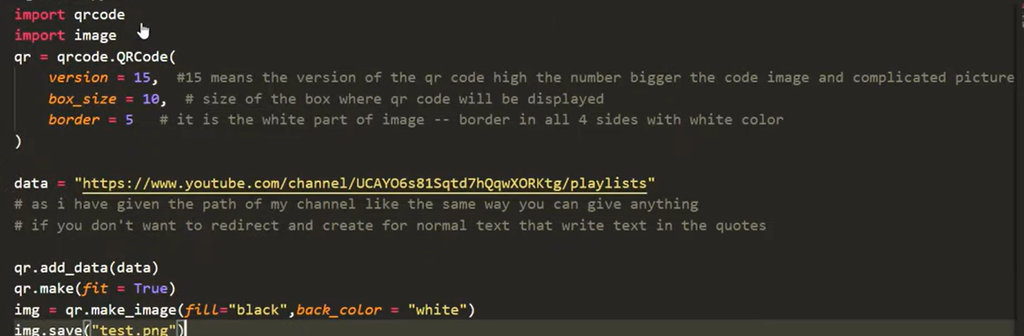

```python
import qrcode
import image
qr = qrcode.QRCode(version=5, error_correction=qrcode.constants.ERROR_CORRECT_H, box_size=10, border=5,)
# qr = qrcode.QRCode(version=1, error_correction=qrcode.constants.ERROR_CORRECT_L, box_size=10, border=4,)
data = "C:/Users/ANKIT DIMRI/.vscode/Complete Programming/Python program/Python tutedude/Open CV[DATA ANALYSIS, DJANGO, FLASK, REST API using DJANGO, WEB SCRAPING , OPEN CV,AUTOMATION WITH SELENIUM, BUILDING A FACEBOOK  AUTO POSTER, TIPS AND TRICS IN PROGRAMMING, NETWORK PROGRAMMING IN PYTHON USING SOCKETS BUILDING A CHAT APPLICATION,]/Screenshot_20230118_121236.png"
# data = "https://vegamovies.rocks/download-the-peripheral-2022-season-1-dual-audio-hindi-amazon-original-480p-720p-1080p-web-dl/"
qr.add_data(data)
qr.make(fit=True)
img = qr.make_image(fill_color ="black",back_color="white")
img.save("test_11.png")
```

#### **Url to qrcode**

```python
import qrcode
def generate_qrcode(text):
    qr = qrcode.QRCode(version=1, error_correction=qrcode.constants.ERROR_CORRECT_L, box_size=10, border=4,)

    qr.add_data(text)
    qr.make(fit=True)
    img = qr.make_image(fill_color ="black",back_color="white")
    img.save("test_11.png")
url = input("Enter your url : ")
generate_qrcode(url)
```

#### 4. **Shutdown app using Python with GUI**

For shutdown your system : os.system(“shutdown /s /t 1”)

For restart your system : os.system(“shutdown /r /t 1”)

For Logout your system : os.system(“shutdown -l”)

```
    Button(master, text="Shutdown", command=shutdown).grid(row=0)
    Button(master, text="Restart", command=restart).grid(row=1)
    Button(master, text="Log out", command=logout).grid(row=2)
```

```python
from tkinter import *
import os
def restart():
    os.system("shutdown /r /t 1")
def restart_time():
    os.system("shutdown /r /t 20")
def logout():
    os.system("shutdown -l")
def shutdown():
    os.system("shutdown /s /t 1")
boot = Tk()
boot.title("Shutdown_App")
boot.geometry("600x600")
boot.config(bg="white")
button_1 = Button(boot,text="Restart", font=("Time New Roman", 12, "bold"),relief=RAISED, cursor="plus",command=restart)
button_1.place(x=240,y=40,height=30,width=150)
button_2 = Button(boot,text="Restart Time", font=("Time New Roman", 8, "bold"),relief=RAISED, cursor="plus",command=restart_time)
button_2.place(x=240,y=90,height=30,width=150)
button_3 = Button(boot,text="Log-Out", font=("Time New Roman", 8, "bold"),relief=RAISED, cursor="plus",command=logout)
button_3.place(x=240,y=140,height=30,width=150)
button_4 = Button(boot,text="Shut-Down", font=("Time New Roman", 8, "bold"),relief=RAISED, cursor="plus",command=shutdown)
button_4.place(x=240,y=190,height=30,width=150)
mainloop()
```

#### 5. **Typing Speed calculator Using Python**

```python
from time import * # we can use all the function directly from this *
import random as ran
def mistake(partest, usertest):
        error = 0
        for i in range(len(partest)): # partest [0 to before end] and the len function [end of the function]
            try:
                if partest[i]!=usertest[i]:
                    error = error + 1
            except :
                error = error + 1
        return error

def Speed_time(time_initial,time_finial,userinput):
    time_delay = time_finial-time_initial
    time_overall = round(time_delay,2) # two digits
    speed = len(userinput)/ time_overall
    return round(speed)

if __name__ == '__main__':
    while True:
        check = input(" Ready to test : Yes/ No:: ")
        if check == "Yes":
            test = ["When the bus arrives, sit near the front. You’ll only take it half the way home today and walk the rest (new year, new you). The man with the book sits at the back of the bus.","Buy the shoes. It’s okay, screw the budget, that’s not this year’s resolution. You deserve this. When the saleswoman asks you if you’ve done much running, laugh and gesture to your mid-section. The woman will blink, force out a half-baked hah. It’s a reaction of discomfort, not cruelty; you made it weird. You don’t know why you feel the need to shame your own body in front of a stranger, but you blame it on her lululemon leggings and air-hostess smile. She makes you nervous. Most people do.", "Thommo rammed a bayonet into the rocky clay and tied a string to it. Thommo, the only one of us over thirty, and therefore responsible, was our Ringie, the supervisor of the Two-up ring. He attached a second bayonet to the other end of the string and, using the bayonets like a giant school compass, drew a perfect circle in the clay soil. It was the 23rd May 1915, just months since I'd left Australia,","He is as nondescript a man as they come. Brown hair, dark eyes, with short, well-kept facial hair. Thin-rimmed glasses, a button-down blue shirt, recently ironed. Grey trousers. Clean shoes. If you ever get out of this, you’re not convinced you could pick him","4: Be More Adventurous! Something is different today. Another moth hits the burning lightbulb and falls dead into your matted hair. The mice, your only companions, have gone quiet. Upstairs, there is more movement than usual, things being dragged along the floor. Your stomach has been flip-flopping since you woke up. Call it intuition. There is the issue of that pesky iron shackle around your ankle. You made a valiant effort by nibbling off your toenails and using them as lock picks, but they were too soft and bendable. You thought about breaking your ankle, but your heel would still be in the way. So now, you turn to the other end of your restraints, the metal rod coming out of the basement floor. At its base it flares out into a square plate, with large iron screws holding it down into the cement.",]
            test_1 = ran.choice(test)
            print("**** Typing Speed Calculator *****\n---------------------------------------\n")
            print(test_1)
            print()
            print()
            time_initial = time()
            userinput = input(" Enter : ")
            time_finial = time()
            print('Speed : ',Speed_time(time_initial,time_finial,userinput),"w/sec")
            print('Error : ', mistake(test_1, userinput))
            print("Time : ",round(time(),2))

        elif check == 'No':
            print("Thank You for using the Speed Test Calculator!")
            break

        else:
            print('Wrong Input!')
```

```
Wrong Input!
Thank You for using the Speed Test Calculator!
```

```
from time import * # we can use all the function directly from this *
from tkinter import *
import random as ran
boot = Tk()
boot.title("Typing_Test_Calculator")
boot.geometry("700x700")
def insert():
    def mistake(partest, usertest):
        error = 0
        for i in range(len(partest)): # partest [0 to before end] and the len function [end of the function]
            try:
                if partest[i]!=usertest[i]:
                    error = error + 1
            except :
                error = error + 1
        return error
    def Speed_time(time_initial,time_finial,userinput):
        time_delay = time_finial-time_initial
        time_overall = round(time_delay,2) # two digits
        speed = len(userinput)/ time_overall
        return round(speed)

    if __name__ == '__main__':
        while True:
            check = input(" Ready to test : Yes/ No:: ")
            if check == "Yes":
                test = ["When the bus arrives, sit near the front. You’ll only take it half the way home today and walk the rest (new year, new you). The man with the book sits at the back of the bus.","Buy the shoes. It’s okay, screw the budget, that’s not this year’s resolution. You deserve this. When the saleswoman asks you if you’ve done much running, laugh and gesture to your mid-section. The woman will blink, force out a half-baked hah. It’s a reaction of discomfort, not cruelty; you made it weird. You don’t know why you feel the need to shame your own body in front of a stranger, but you blame it on her lululemon leggings and air-hostess smile. She makes you nervous. Most people do.", "Thommo rammed a bayonet into the rocky clay and tied a string to it. Thommo, the only one of us over thirty, and therefore responsible, was our Ringie, the supervisor of the Two-up ring. He attached a second bayonet to the other end of the string and, using the bayonets like a giant school compass, drew a perfect circle in the clay soil. It was the 23rd May 1915, just months since I'd left Australia,","He is as nondescript a man as they come. Brown hair, dark eyes, with short, well-kept facial hair. Thin-rimmed glasses, a button-down blue shirt, recently ironed. Grey trousers. Clean shoes. If you ever get out of this, you’re not convinced you could pick him","4: Be More Adventurous! Something is different today. Another moth hits the burning lightbulb and falls dead into your matted hair. The mice, your only companions, have gone quiet. Upstairs, there is more movement than usual, things being dragged along the floor. Your stomach has been flip-flopping since you woke up. Call it intuition. There is the issue of that pesky iron shackle around your ankle. You made a valiant effort by nibbling off your toenails and using them as lock picks, but they were too soft and bendable. You thought about breaking your ankle, but your heel would still be in the way. So now, you turn to the other end of your restraints, the metal rod coming out of the basement floor. At its base it flares out into a square plate, with large iron screws holding it down into the cement.",]
                test_1 = ran.choice(test)
                print("**** Typing Speed Calculator *****\n---------------------------------------\n")
                print(test_1)
                print()
                print()
                time_initial = time()
                userinput = input(" Enter : ")
                time_finial = time()
                print('Speed : ',Speed_time(time_initial,time_finial,userinput),"w/sec")
                print('Error : ', mistake(test_1, userinput))
                print("Time : ",round(time(),2))

            elif check == 'No':
                print("Thank You for using the Speed Test Calculator!")
                break

            else:
                print('Wrong Input!')

button_1 = Button(boot,text="", font=("Time New Roman", 12, "bold"),relief=RAISED, cursor="plus",command=insert)
button_1.place(x=240,y=40,height=30,width=150)
mainloop()
```

#### **Typing Geeks for Geeks**

```python
# importing all libraries
from tkinter import *
from timeit import default_timer as timer
import random

# creating window using gui
window = Tk()

# the size of the window is defined
window.geometry("450x200")

x = 0

# defining the function for the test
def game():
	global x

	# loop for destroying the window
	# after on test
	if x == 0:
		window.destroy()
		x = x+1

	# defining function for results of test
	def check_result():
		if entry.get() == words[word]:

			# here start time is when the window
			# is opened and end time is when
			# window is destroyed
			end = timer()

			# we deduct the start time from end
			# time and calculate results using
			# timeit function
			print(end-start)
		else:
			print("Wrong Input")

	words = ['programming', 'coding', 'algorithm',
			'systems', 'python', 'software']

	# Give random words for testing the speed of user
	word = random.randint(0, (len(words)-1))

	# start timer using timeit function
	start = timer()
	windows = Tk()
	windows.geometry("450x200")

	# use label method of tkinter for labeling in window
	x2 = Label(windows, text=words[word], font="times 10")

	# place of labeling in window
	x2.place(x=150, y=10)
	x3 = Label(windows, text="Start Typing", font="times 20")
	x3.place(x=10, y=50)

	entry = Entry(windows)
	entry.place(x=280, y=55)

	# buttons to submit output and check results
	b2 = Button(windows, text="Done",
				command=check_result, width=12, bg='grey')
	b2.place(x=150, y=100)

	b3 = Button(windows, text="Try Again",
				command=game, width=12, bg='grey')
	b3.place(x=250, y=100)
	windows.mainloop()


x1 = Label(window, text="Lets start playing..", font="times 20")
x1.place(x=10, y=50)

b1 = Button(window, text="Go", command=game, width=12, bg='grey')
b1.place(x=150, y=100)

# calling window
window.mainloop()
```

#### **Convert UTC timezone to IST python**

```python
from datetime import datetime
from zoneinfo import ZoneInfo
datetime_1 = datetime.now(ZoneInfo('Asia/Kolkata'))
print("India Time:",datetime_1)
import pytz
datetime_NY = datetime.now(pytz.timezone('Asia/Kolkata'))
print("India time:", datetime_NY.strftime("%Y-%m-%d %H:%M:%S.%f"))
```

```
India Time: 2023-01-27 12:25:01.889861+05:30
India time: 2023-01-27 12:25:02.138467
```

#### 6. **Internet Speed Test using Python with GUI**

- [pip install speedtest-cli]
- [

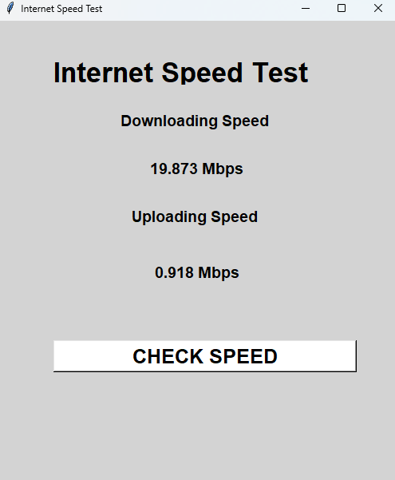

  ]

```python
from tkinter import *
import speedtest
def speedcheck():
    boot = speedtest.Speedtest()
    boot.get_servers()
    down = str(round(boot.download()/(10**6),3)) + " Mbps"
    up = str(round(boot.upload()/(10**6),3)) + " Mbps"
    label_down.config(text=down)
    label_up.config(text=up)

boot = Tk()
boot.title(" Internet Speed Test ")
boot.geometry("500x600")
boot.config(bg="lightgrey")
label = Label(boot, text="Internet Speed Test", font=("Time New Roman", 26,"bold"),bg="lightgrey", fg="black")
label.place(x=40,y=50,height=30,width=380)
label = Label(boot, text="Downloading Speed ", font=("Time New Roman", 14,"bold"),bg="lightgrey", fg="black")
label.place(x=60,y=110,height=30,width=380)

label_down = Label(boot, text="00", font=("Time New Roman", 14,"bold"),bg="lightgrey", fg="black")
label_down.place(x=60,y=170,height=30,width=380)
label = Label(boot, text="Uploading Speed ", font=("Time New Roman", 14,"bold"),bg="lightgrey", fg="black")
label.place(x=60,y=230,height=30,width=380)

label_up = Label(boot, text="00", font=("Time New Roman", 14,"bold"),bg="lightgrey", fg="black")
label_up.place(x=60,y=300,height=30,width=380)

button_1 = Button(boot,text="CHECK SPEED",font=("Time New Roman", 19,"bold"),bg="white", fg="black",relief=RAISED,command=speedcheck)
button_1.place(x=70,y=400,height=40,width=380)
boot.mainloop()
```

#### 7. **Text To Handwritting Using Python**

- [Successfully installed Flask-2.2.2 Jinja2-3.1.2 MarkupSafe-2.1.2 Werkzeug-2.2.2 itsdangerous-2.1.2 pywhatkit-5.4 wikipedia-1.4.0]

```python
import pywhatkit

pywhatkit.text_to_handwriting("When the bus arrives, sit near the front. Youll only take it half the way home today and walk the rest (new year, new you). The man with the book sits at the back of the bus.","xn.png",[0,0,138])
print(" END ")
```

```
 END
```

```python
import pywhatkit as kit
import cv2

kit.text_to_handwriting("Hope you are doing well", save_to="handwriting.png")
# img = cv2.imread("handwriting.png")
# cv2.imshow("Text to Handwriting", img)
cv2.waitKey(0)
cv2.destroyAllWindows()
```

```
    import pywhatkit

    # Send a WhatsApp Message to a Contact at 1:30 PM
    pywhatkit.sendwhatmsg("9760763472", "Hi", 13, 30)

    # Same as above but Closes the Tab in 2 Seconds after Sending the Message
    # pywhatkit.sendwhatmsg("+919760763472", "Hi", 13, 30, 15, True, 2)

    # Send an Image to a Group with the Caption as Hello
    # pywhatkit.sendwhats_image("AB123CDEFGHijklmn", "Images/Hello.png", "Hello")

    # Send an Image to a Contact with the no Caption
    # pywhatkit.sendwhats_image("+919760763472", "Images/Hello.png")

    # Send a WhatsApp Message to a Group at 12:00 AM
    # pywhatkit.sendwhatmsg_to_group("AB123CDEFGHijklmn", "Hey All!", 0, 0)

    # Send a WhatsApp Message to a Group instantly
    # pywhatkit.sendwhatmsg_to_group_instantly("AB123CDEFGHijklmn", "Hey All!")

    # Play a Video on YouTube
    pywhatkit.playonyt("PyWhatKit")
```

#### 8. **YouTube Video Downloader**

> pip install pytube==12.1.2

```python
from pytube import YouTube
link = "https://www.youtube.com/watch?v=obOhIAg39IQ"
YouTube_1 = YouTube(link)
print(YouTube_1.title)
print(YouTube_1.thumbnail_url)
# videos = YouTube_1.streams.all() # video format
videos = YouTube_1.streams.filter(only_audio=True) # for the audio format
vid = list(enumerate(videos))
for i in vid :
    print(i)
print()
stream = int(input("Enter  : "))
videos[stream].download()
print('Successfully')
```

```
why are you always in a mood? pt.2 | a playlist
https://i.ytimg.com/vi/obOhIAg39IQ/sddefault.jpg?sqp=-oaymwEmCIAFEOAD8quKqQMa8AEB-AH-CYAC0AWKAgwIABABGGUgRChDMA8=&rs=AOn4CLBMhCjERStEedN7Q-16P9FZ9BCNrw
(0, <Stream: itag="139" mime_type="audio/mp4" abr="48kbps" acodec="mp4a.40.5" progressive="False" type="audio">)
(1, <Stream: itag="140" mime_type="audio/mp4" abr="128kbps" acodec="mp4a.40.2" progressive="False" type="audio">)
(2, <Stream: itag="249" mime_type="audio/webm" abr="50kbps" acodec="opus" progressive="False" type="audio">)
(3, <Stream: itag="250" mime_type="audio/webm" abr="70kbps" acodec="opus" progressive="False" type="audio">)
(4, <Stream: itag="251" mime_type="audio/webm" abr="160kbps" acodec="opus" progressive="False" type="audio">)

Successfully
```

#### **For download to Complete playlist for low quality videos**

```python
from pytube import Playlist
link = Playlist("https://www.youtube.com/playlist?list=PLjVLYmrlmjGeAqSjAFPXXMSGg5ut2ghvS")
print(f'Downloading : {link.title}')
for  video in link.videos:
    video.streams.first().download()
```

```
Downloading : Learn PLC | PLC Programming | PLC Tutorials | Allen Bradley MicroLogix 1100 | RS Logix 500
```

#### 9. **Desktop Notifier using Python ( Python code run in the background )**

> pip install plyer==2.1.0

```python
from plyer import notification
import time

if __name__ == '__main__':
    while True:
        notification.notify(
            title="*****Take_Rest******",
            message="Rest is vital for better mental health, increased concentration and memory, a healthier immune system, reduce stress, improved mood and even better metabolism.",
            app_icon ="C:/Users/ANKIT DIMRI/.vscode/Complete Programming/Python program/Python tutedude/Python_Complete_project/ico.ico",
            timeout = 5)
        time.sleep(20) # 60*60 after one hour

# command prompt
# goto the task manager  and end the task if you don't get the close setting of the program
```

#### 10. **Convert Python File to exe(1.pyintaller, 2. auto-py-to-exe)**

> pip install pyinstaller==5.7.0

> Successfully installed altgraph-0.17.3 pefile-2022.5.30 pyinstaller-5.7.0 pyinstaller-hooks-contrib-2022.15 pywin32-ctypes-0.2.0

> pyinstaller pythonfilename cmd

> pyinstaller --onefile filename cmd

> pip install auto-py-to-exe==2.27.0

> auto-py-to-exe then after set the setting...
- [

[figure not shown]

  ]

#### 11. **Digital Clock Using Python With GUI**

```python
from tkinter import *
import datetime

def date_time():
    time = datetime.datetime.now()
    hour = time.strftime('%I')
    mi = time.strftime('%M')
    sec = time.strftime('%S')
    am = time.strftime('%p')
    ms = time.strftime('%f')

    date = time.strftime("%d")
    month = time.strftime('%m')
    year = time.strftime('%y')
    day = time.strftime('%a')

    l_hr.config(text=hour)
    l_min.config(text=mi)
    l_sec.config(text=sec)
    l_am.config(text=am)
    l_ms.config(text=ms)

    l_date.config(text=date)
    l_mo.config(text=month)
    l_year.config(text=year)
    l_day.config(text=day)

    l_hr.after(200,date_time)


clock = Tk()
clock.title('Digital Clock')
clock.geometry('900x500')
clock.config(bg='white')
l_hr = Label(clock, text="hour",font=('Time New Roman',40,"bold"),bg='white',fg='black')
l_hr.place(x = 170, y = 70, height=70,width=60)
l_hr_txt = Label(clock, text="Hour",font=('Time New Roman',20,"bold"),bg='white',fg='black')
l_hr_txt.place(x = 160, y = 170, height=70,width=70)

l_min = Label(clock, text="mi",font=('Time New Roman',38,"bold"),bg='white',fg='black')
l_min.place(x = 340, y = 70, height=70,width=60)
l_min_txt = Label(clock, text="Min.",font=('Time New Roman',19,"bold"),bg='white',fg='black')
l_min_txt.place(x = 330, y = 170, height=70,width=70)

l_sec = Label(clock, text="sec",font=('Time New Roman',36,"bold"),bg='white',fg='black')
l_sec.place(x = 510, y = 70, height=70,width=60)
# micro second  new fun
l_ms = Label(clock, text="00",font=('Time New Roman',18,"bold"),bg='white',fg='black')
l_ms.place(x = 600, y = 70, height=100,width=100) # special for the microsecond
l_sec_txt = Label(clock, text="Sec.",font=('Time New Roman',18,"bold"),bg='white',fg='black')
l_sec_txt.place(x = 500, y = 170, height=70,width=70)


l_am = Label(clock, text="am",font=('Time New Roman',25,"bold"),bg='white',fg='black')
l_am.place(x = 730, y = 70, height=70,width=60)
l_am_txt = Label(clock, text="AM-PM",font=('Time New Roman',13,"bold"),bg='white',fg='black')
l_am_txt.place(x = 720, y = 170, height=70,width=80)

# For date format
l_date = Label(clock, text="00",font=('Time New Roman',40,"bold"),bg='white',fg='black')
l_date.place(x = 170, y = 300, height=70,width=60)
l_date_txt = Label(clock, text="Date",font=('Time New Roman',20,"bold"),bg='white',fg='black')
l_date_txt.place(x = 160, y = 380, height=70,width=70)

l_mo = Label(clock, text="00",font=('Time New Roman',38,"bold"),bg='white',fg='black')
l_mo.place(x = 340, y = 300, height=70,width=60)
l_mo_txt = Label(clock, text="Month",font=('Time New Roman',19,"bold"),bg='white',fg='black')
l_mo_txt.place(x = 330, y = 380, height=70,width=90)

l_year = Label(clock, text="00",font=('Time New Roman',36,"bold"),bg='white',fg='black')
l_year.place(x = 510, y = 300, height=70,width=60)
l_year_txt = Label(clock, text="Year",font=('Time New Roman',18,"bold"),bg='white',fg='black')
l_year_txt.place(x = 500, y = 380, height=70,width=70)

l_day = Label(clock, text="00",font=('Time New Roman',26,"bold"),bg='white',fg='black')
l_day.place(x = 680, y = 300, height=70,width=80)
l_day_txt = Label(clock, text="Day",font=('Time New Roman',15,"bold"),bg='white',fg='black')
l_day_txt.place(x = 670, y = 380, height=70,width=90)

date_time()
clock.mainloop()
```

#### 12 **Python Number Details using Python**

> pip install phonenumbers==8.13.4

```python
import phonenumbers
from phonenumbers import timezone, geocoder, carrier
number = input('Enter Your Phone Number : ')
phone = phonenumbers.parse(number)
time = timezone.time_zones_for_number(phone)
carr = carrier.name_for_number(phone,"en")
registration = geocoder.description_for_number(phone,"en")
print(phone)
print(time)
print(carr)
print(registration)
```

```
Country Code: 91 National Number: 9870772993
('Asia/Calcutta',)
Reliance Jio
India
```

#### 13. **Instagram Automation using Python**

> pip install instabot==0.117.0

> Other Topics

> pip install banner==0.0.2

> pip install colour==0.1.5

```python
from instabot import Bot
bot = Bot()
bot.login(username="hobhisdobhal", password='mikkumicro@123')
bot.follow('nike') # unfollow command just type the unfollow
bot.upload_photo("C:/Users/ANKIT DIMRI/.vscode/Complete Programming/Python program/Python tutedude/Python_Complete_project/digital-clock.png",caption="The time is eternal")
bot.send_message("No",["username"],["other username"])
followers = bot.get_user_followers("hobhisdobhal")
for follower in followers:
    print(bot.get_user_info(follower))

followings = bot.get_user_following("hobhisdobhal")
for following in followings:
    print(bot.get_user_info(following))
```

#### 14.**Website Blocker Using Python**

- [

[figure not shown]

  ]

```python
import datetime
import time
import os

end_time = datetime.datetime(2023,12,30)
site_block = ["www.kayak.co","www.facebook.com"]
host_path = "C:/Windows/System32/drivers/etc/hosts"
redirect_number = "127.0.0.1"
while True:
    if datetime.datetime.now()<end_time:
        print('Start Blocking') # through file handing
        with open(host_path,"r+") as host_file:
            content = host_file.read()
            for website in site_block:
                if website not in content:
                    host_file.write(redirect_number + " " +website +"\n")
                else:
                    pass
    else:
        with open(host_path,"r+") as host_file :
            content = host_file.readlines()
            host_file.seek(0)
            for lines in content:
                if not any(website in lines for website in site_block):
                    host_file.write(lines)
            host_file.truncate()
        time.sleep(5)
```

#### 15. **Skype Automation Using Python**

> pip install SkPy==0.10.4

```python
from skpy import Skype
import os.path
slogin = Skype("hobbitrobo17@gmail.com","xxxxxxxxxxxxx")
contact = slogin.contacts["live:.cid.baf6bc8cfa45c321"]
contact.chat.sendMsg("Welcome Brother!")
with open("C:/Users/ANKIT DIMRI/.vscode/Complete Programming/Python program/Python tutedude/Python_Complete_project/digital-clock.ico","rb") as f:
    contact.chat.sendFile(f,"digital-clock.ico",image=True)

# for i in contact:
#     print(i) # to get all the details of the contacts
# groups = slogin.chats.create(["user id","other user id","one more other"])
```

#### 16. **Voice Assistant Using Python**

```python
import pyttsx3
import speech_recognition as sr
import webbrowser
import datetime
import pyjokes
import os
import time


def sptext():
    recognizer = sr.Recognizer()
    with sr.Microphone() as source:
        print('Listening......')
        recognizer.adjust_for_ambient_noise(source)
        audio = recognizer.listen(source)
        try:
            print('Reconizing.....')
            data = recognizer.recognize_google(audio)
            print(data)
            return data
        except sr.UnknownValueError:
            print(' Not recognize....')

def speechtx(x):
    engine = pyttsx3.init()
    voices = engine.getProperty('voices')
    engine.setProperty('voice',voices[1].id)# for the male voice and 1  for female
    rate = engine.getProperty('rate')
    engine.setProperty('rate',140)
    engine.say(x)
    engine.runAndWait()


if __name__ == '__main__':

    if "hello" in sptext().lower():

        while True:
            data1 = sptext().lower()

            if "your name" in data1:
                name = " my name is peter "
                speechtx(name)

            elif "old are you" in data1:
                age = "I am two years old"
                speechtx(age)

            elif 'time' in data1:
                time = datetime.datetime.now().strftime("%I%M%p")
                speechtx(time)

            elif 'youtube' in data1:
                webbrowser.open("https://www.youtube.com/watch?v=OKuiyX5k6zg&list=WL&index=2&t=18398s")

            elif 'web' in data1:
                webbrowser.open("https://www.wscubetech.com/")

            elif "joke" in data1:
                joke_1 = pyjokes.get_joke(language="en",category="neutral")
                print(joke_1)
                speechtx(joke_1)
            elif "song" in data1:
                add = "C:/Users/ANKIT DIMRI/Downloads/yes" # only take the path of folder not the complete file address
                listsong = os.listdir(add)
                print(listsong)
                os.startfile(os.path.join(add,listsong[0]))

            elif "exit" in data1:
                speechtx("Thank you for using this Application")
                break
            time.sleep(5)

    else:
        print('Thank You!!')
```

```
Listening......
Reconizing.....
result2:
{   'alternative': [{'confidence': 0.88687539, 'transcript': 'hello'}],
    'final': True}
hello
Listening......
Reconizing.....
result2:
{   'alternative': [   {'confidence': 0.88687539, 'transcript': 'exit'},
                       {'transcript': 'exit exit'},
                       {'transcript': 'exam'},
                       {'transcript': 'exam exit'}],
    'final': True}
exit
```

```python
import pyttsx3
def onStart(name):
   print ('starting', name)
def onWord(name, location, length):
   print ('word', name, location, length)
def onEnd(name, completed):
   print ('finishing', name, completed)
engine = pyttsx3.init()
engine.connect('started-utterance', onStart)
engine.connect('started-word', onWord)
engine.connect('finished-utterance', onEnd)
engine.say('The quick brown fox jumped over the lazy dog. Hello Ritik ... I am so happy to see You!')
engine.runAndWait()
```

```
starting None
starting None
word None 1 901120
word None 1 901120
finishing None True
finishing None True
```

#### 17. **Gmail Automation**

> pip install pySMTP

```python
import smtplib as s
ob  = s.SMTP('smtp.gmail.com',587) # 465 587 port number
ob.ehlo()
ob.starttls()
ob.login('geekmicrosoft254@gmail.com','xxxxxxxx')
subject = "test python"
body = "I love Gmail.."
message = "subject:{}\n\n{}".format(subject,body)
listadd = ['dimri.ankitdimri@gmail.com',"hobbitrobo17@gmail.com"]
ob.sendmail('geekmicrosoft254@gmail.com',listadd,message)
print("Send mail....")
ob.quit()
```

#### 18. **Google Translate Using Python With GUI**

> pip install googletrans

> Successfully installed chardet-3.0.4 googletrans-3.0.0 h11-0.9.0 h2-3.2.0 hpack-3.0.0 hstspreload-2023.1.1 httpcore-0.9.1 httpx-0.13.3 hyperframe-5.2.0 idna-2.10 rfc3986-1.5.0

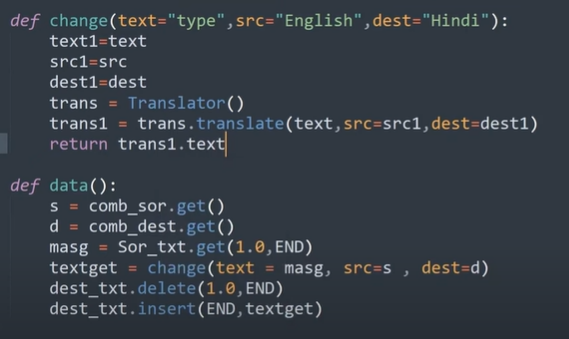

```python
from tkinter import *
from tkinter import ttk
from googletrans import Translator, LANGUAGES

def change(text="type",source_text="English",destination_text="Hindi"):
    text_1 = text
    source_text_1 = source_text
    destination_text_1 = destination_text
    translator = Translator()
    translator_1 = translator.translate(text=text_1,source_text=source_text_1,destination_text=destination_text_1)
    return translator_1.text

def data():
    s = comb_source.get()
    d = comb_source.get()
    message = source_text.get(1.0,END)
    textget = change(text=message, source_text=s,destination_text=d)
    destination_text.delete(1.0,END)
    destination_text.insert(END,textget)

root = Tk()
root.title("A-Translator")
root.geometry("700x800")
# root.config(bg="white")
label_txt = Label(root,text="Translator", font=("Time New Roman",32,"bold"),fg="darkred")
label_txt.place(x = 250,y = 50,height=70,width=250)

frame = Frame(root).pack(side=BOTTOM)
label_txt = Label(root,text="Source Text", font=("Time New Roman",18,"bold"),fg="black")
label_txt.place(x = 270,y = 120,height=70,width=200)

source_text = Text(frame,font=("Time New Roman",15,"bold"),wrap=WORD,fg="green")
source_text.place(x = 40,y = 180,height=140,width=620)

list_text = list(LANGUAGES.values())
comb_source = ttk.Combobox(frame,value=list_text)
comb_source.place(x = 40,y = 380,height=30,width=210)
comb_source.set("english")

button_change = Button(frame,text="Translate",relief=RAISED,command=data)
button_change.place(x=290,y=380,height=30,width=140)

comb_source = ttk.Combobox(frame,value=list_text)
comb_source.place(x=470,y=380,height=30,width=210)
comb_source.set("hindi")

label_txt = Label(root,text="Destination Text", font=("Time New Roman",18,"bold"),fg="black")
label_txt.place(x = 245,y = 450,height=70,width=250)

destination_text = Text(frame,font=("Time New Roman",15,"bold"),wrap=WORD,fg="green")
destination_text.place(x = 40,y = 530,height=140,width=620)

root.mainloop()
```

#### 19. **Python File ( .py ) To Convert Into Mobile App ( .apk )**

- [

[figure not shown]

  ]

> pip install kivymd==1.1.1

> **Python File To Convent Into Apk**

!pip install buildozer !pip install cython==0.29.19

!sudo apt-get install -y  
python3-pip  
build-essential  
git  
python3  
python3-dev  
ffmpeg  
libsdl2-dev  
libsdl2-image-dev  
libsdl2-mixer-dev  
libsdl2-ttf-dev  
libportmidi-dev  
libswscale-dev  
libavformat-dev  
libavcodec-dev  
zlib1g-dev

!sudo apt-get install -y  
libgstreamer1.0  
gstreamer1.0-plugins-base  
gstreamer1.0-plugins-good

!sudo apt-get install build-essential libsqlite3-dev sqlite3 bzip2 libbz2-dev zlib1g-dev libssl-dev openssl libgdbm-dev libgdbm-compat-dev liblzma-dev libreadline-dev libncursesw5-dev libffi-dev uuid-dev libffi6

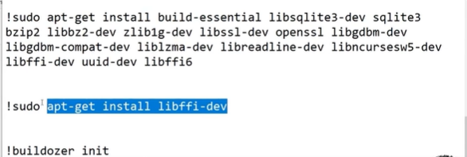

#### **first import your python file**

> !buildozer init
- [

[figure not shown]

  ] then goto the
- [

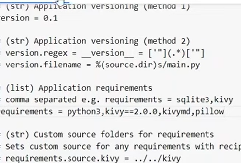

  ]
- [

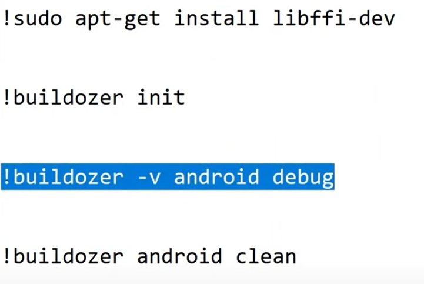

  ]
- [

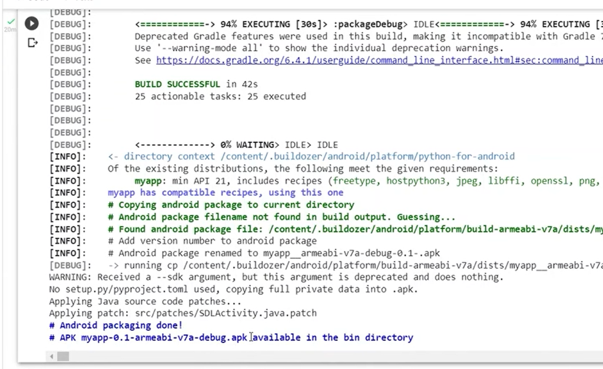

  ]

```python
from kivymd.app import MDApp
from kivymd.uix.label import MDLabel
class Main_App(MDApp):
    def build(self):
        return MDLabel(text="Welcome to Techee World!",halign="center")
if __name__ == '__main__':
    Main_App().run()
```

#### 20. **Screen recorder Using Python**

- **pip install opencv-python**
- **pip install pywin32**
- **pip install numpy**
- **pip install pyautogui**

```python
import cv2
import pyautogui
from win32api import GetSystemMetrics
import numpy as np
import time

width = GetSystemMetrics(0)
height = GetSystemMetrics(1)
dim = (width,height)
f = cv2.VideoWriter_fourcc(*"XVID")
output = cv2.VideoWriter("test.mp4",f,30.0,dim)
now_start_time = time.time()
dur = 10
end_time = now_start_time + dur
while True:
    image = pyautogui.screenshot()
    frame1 = np.array(image)
    frame = cv2.cvtColor(frame1,cv2.COLOR_BGR2RGB)
    output.write(frame)
    c_time = time.time()
    if c_time > end_time:
        break
output.release()
print('------End-------')
```

```
------End-------
```

#### 21. **Python project Face Detection Using Python**

> Open CV

for enable the camera

```python
import cv2
video_cap = cv2.VideoCapture(0)
while True:
    ret, video_data = video_cap.read()
    cv2.imshow("video_live",video_data)
    if cv2.waitKey(10) == ord("a"):
        break
video_cap.release()
```

> face detection get the file from the library :

> C:\Users\ANKIT DIMRI\AppData\Local\Programs\Python\Python311\Lib\site-packages\cv2\data

```python
import cv2
face_cap = cv2.CascadeClassifier("C:/Users/ANKIT DIMRI/AppData/Local/Programs/Python/Python311/Lib/site-packages/cv2/data/haarcascade_frontalface_default.xml")
video_cap = cv2.VideoCapture(0)
while True:
    ret, video_data = video_cap.read()
    col = cv2.cvtColor(video_data,cv2.COLOR_BGR2GRAY)
    faces = face_cap.detectMultiScale(
        col,
        scaleFactor=1.1,
        minNeighbors=5,
        minSize=(30,30),
        flags=cv2.CASCADE_SCALE_IMAGE
    )
    for (x,y,w,h) in faces:
        cv2.rectangle(video_data,(x,y),(x+w,y+h),(0,255,0),2)
    cv2.imshow("video_live",video_data)
    if cv2.waitKey(10) == ord("a"):
        break
video_cap.release()
```

#### 22. **Password Wordlist Using Python for Brute Force Attack**

> **two types of modules are requires string and iterations modules**

```python
from string import *
value = ascii_letters #for the alphabetical order in upper or lower case
value1 = punctuation # special character
value2 = digits
print(value)
print(value1)
print(value2)
```

```
abcdefghijklmnopqrstuvwxyzABCDEFGHIJKLMNOPQRSTUVWXYZ
!"#$%&'()*+,-./:;<=>?@[\]^_`{|}~
0123456789
```

```python
from itertools import product
value = ascii_letters + digits + punctuation
for i in range(1,4):
    for j in product(value,repeat=i):
        word = "".join(j)
        p = open("Password.txt","a")
        p.write(word)
        p.write("\t")
```

#### 23. **Weather App Using Python**

> pip install indian-cities
- [

[figure not shown]

  ]
- [

[figure not shown]

  ]

```python
import requests
city_name = "dehradun"
data = requests.get("https://api.openweathermap.org/data/2.5/weather?q="+city_name+"&appid=xxxxxxxxxxxxxxxxxxxxxxx").json()
print(data)
```

```python
from tkinter import *
from indian_cities.dj_city import cities
from tkinter import ttk  # combo box
import requests
def data_get():
    city = city_name.get()
    data = requests.get("https://api.openweathermap.org/data/2.5/weather?q="+city+"&appid=xxxxxxxxxxxxxxxxxxxxxxxxx").json()
    weather_label1.config(text=data["weather"][0]["main"])
    weather_description_label1.config(text=data["weather"][0]['description'])
    temp_label1.config(text=str(int(data["main"]["temp"]-273.15)))
    hum_label1.config(text=data["main"]["humidity"])
    feels_lk_label1.config(text=str(data["main"]["feels_like"]-273.15))
    pres_label1.config(text=data["main"]["pressure"])
boot = Tk()
boot.title("Weather App")
boot.geometry("500x640")
name_label = Label(boot, text="Weather Application", font=("Time New Roman",30,"bold"))
name_label.place(x=50,y=40,height=70,width=400)
city_name = StringVar()
list_name = ["Andhra Pradesh","Arunachal Pradesh ","Assam","Bihar","Chhattisgarh","Goa","Gujarat","Haryana","Himachal Pradesh","Jammu and Kashmir","Jharkhand","Karnataka","Kerala","Madhya Pradesh","Maharashtra","Manipur","Meghalaya","Mizoram","Nagaland","Odisha","Punjab","Rajasthan","Sikkim","Tamil Nadu","Telangana","Tripura","Uttar Pradesh","Uttarakhand","West Bengal","Andaman and Nicobar Islands","Chandigarh","Dadra and Nagar Haveli","Daman and Diu","Lakshadweep","National Capital Territory of Delhi","Puducherry"]
# list_name = cities
com = ttk.Combobox(boot, text="Weather Application", values=list_name ,font=("Time New Roman",12,"bold"),textvariable=city_name)
com.place(x=100,y=140,height=30,width=300)
# five button
weather_label = Label(boot, text="Weather Climate : ", font=("Time New Roman",12,"bold"))
weather_label.place(x=25,y=300,height=40,width=190)
weather_label1 = Label(boot, text="", font=("Time New Roman",12,"bold"))
weather_label1.place(x=227,y=300,height=40,width=110)

weather_description_label = Label(boot, text="Weather Description : ", font=("Time New Roman",12,"bold"))
weather_description_label.place(x=35,y=350,height=40,width=200)
weather_description_label1 = Label(boot, text="", font=("Time New Roman",12,"bold"))
weather_description_label1.place(x=230,y=350,height=40,width=170)

temp_label = Label(boot, text="Temp : ", font=("Time New Roman",12,"bold"))
temp_label.place(x=28,y=400,height=40,width=100)
temp_label1 = Label(boot, text="", font=("Time New Roman",12,"bold"))
temp_label1.place(x=210,y=400,height=40,width=100)

hum_label = Label(boot, text="Humidity : ", font=("Time New Roman",12,"bold"))
hum_label.place(x=28,y=450,height=40,width=130)
hum_label1 = Label(boot, text="", font=("Time New Roman",12,"bold"))
hum_label1.place(x=210,y=450,height=40,width=100)

feels_lk_label = Label(boot, text="Feels-Like : ", font=("Time New Roman",12,"bold"))
feels_lk_label.place(x=33,y=500,height=40,width=130)
feels_lk_label1 = Label(boot, text="", font=("Time New Roman",12,"bold"))
feels_lk_label1.place(x=230,y=500,height=40,width=200)

pres_label = Label(boot, text="Pressure : ", font=("Time New Roman",12,"bold"))
pres_label.place(x=28,y=550,height=40,width=130)
pres_label1 = Label(boot, text="", font=("Time New Roman",12,"bold"))
pres_label1.place(x=219,y=550,height=40,width=100)


done_button = Button(boot,text="Done",font=("Time New Roman",18,"bold"),fg="darkred",command=data_get)
done_button.place(x=200,y=200,height=40,width=100)

boot.mainloop()
```

#### 24. **Take Screeenshot using Python**

```python
from tkinter import *
import pyautogui

def take_ss():
    add_data = entry.get()
    path = add_data+"\\test12.png"
    ss = pyautogui.screenshot()
    print(path)
    ss.save(path)

boot = Tk()
boot.title("Screenshot")
boot.geometry("300x300")
boot.resizable(False,False)

entry = Entry(boot,text="Done",font=("Time New Roman",12,"bold"))
entry.place(x=30,y=60,height=100,width=250)

button = Button(boot,text="Done",font=("Time New Roman",18,"bold"),command=take_ss)
button.place(x=100,y=180,height=40,width=100)

mainloop()
# enter the input - C:\Users\ANKIT DIMRI\.vscode\Complete Programming\Python program\Python tutedude\Python_Complete_project
```

#### 25. **File Manager Using Python**

multiple clusttered files to save in the different files folder

- [

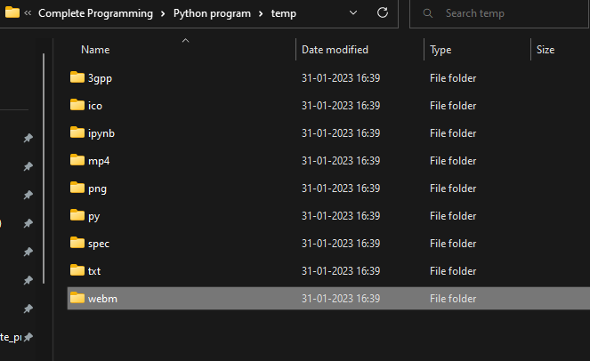

  ]

```python
import os
import shutil # transfer file from one place to another
path = input("Enter your Path : ")
files = os.listdir(path)
for i in files:
    # print(i)
    filename, extension = os.path.splitext(i)
    extension_1 = extension[1:]
    folder_path = path+"\\"+extension_1
    if os.path.exists(folder_path):
        shutil.move(path+"\\"+i, path+"\\"+extension_1+"\\"+i)
    else:
        os.makedirs(folder_path)
        shutil.move(path+"\\"+i, path+"\\"+extension_1+"\\"+i)
```

#### 26. **Convert Image into ASCII art using Python**

all the special character to make a complete image

> pip install pywhatkit

> pip install ascii-magic

```python
import pywhatkit as kit
kit.image_to_ascii_art("C:/Users/ANKIT DIMRI/.vscode/Complete Programming/Python program/Python tutedude/Python_Complete_project/Yes.png","ascii.txt")
```

```python
# import ascii_magic
# output = ascii_magic.from_image_file("C:/Users/ANKIT DIMRI/.vscode/Complete Programming/Python program/Python tutedude/Python_Complete_project/test.png", columns=300,char="")
# ascii_magic.to_terminal(output)
```

#### 27. **Convert image into Pencil Sketch**

```python
import cv2
image = cv2.imread("test.png")
grey_img = cv2.cvtColor(image, cv2.COLOR_BGR2GRAY)
invert = cv2.bitwise_not(grey_img)
blur = cv2.GaussianBlur(invert,(21,21),0)
invertedblur = cv2.bitwise_not(blur)
sketch = cv2.divide(grey_img,invertedblur,scale=256.0)
```

```python
import kivy
from kivy.app import App
from kivy.uix.gridlayout import GridLayout
from kivy.uix.label import Label
from kivy.uix.textinput import TextInput
from kivy.uix.button import Button

class childApp(GridLayout):
    def __init__(self,**kwargs): # so we can implement lots of function
        super(childApp,self).__init__()
        self.cols = 2
        self.add_widget(Label(text='Student Name'))
        self.s_name = TextInput()
        self.add_widget(self.s_name)

        self.add_widget(Label(text='Student Marks'))
        self.s_marks = TextInput()
        self.add_widget(self.s_marks)

        self.add_widget(Label(text='Student Gender'))
        self.gender = TextInput()
        self.add_widget(self.gender)

        self.press = Button(text = 'Click me')
        self.press.bind(on_press = self.click_me)
        self.add_widget(self.press)

    def click_me(self,instance):
        print("Name of Student is : "+self.s_name.text)
        print("Makrs of Student is : "+self.s_marks.text)
        print("Get of Student is : "+self.s_gender.text)
        print("")

class parentApp(App):
    def build(self):
        return childApp()
|
if __name__ == " __main__":
    parentApp().run()
```